# Mini Project: Monte Carlo Methods

In this notebook, you will write your own implementations of many Monte Carlo (MC) algorithms.

While we have provided some starter code, you are welcome to erase these hints and write your code from scratch.

### Part 0: Explore BlackjackEnv

Use the code cell below to create an instance of the [Blackjack](https://github.com/openai/gym/blob/master/gym/envs/toy_text/blackjack.py) environment.

```python
# in this cell the environment is loaded

import gym
env = gym.make('Blackjack-v0')
```

Each state is a 3-tuple of:

- the player's current sum $\in \{0, 1, \ldots, 31\}$,
- the dealer's face up card $\in \{1, \ldots, 10\}$, and
- whether or not the player has a usable ace (`no` $=0$, `yes` $=1$).

The agent has two potential actions:

```
    STICK = 0
    HIT = 1
```

Verify this by running the code cell below.

```python
# first exploration of the environment

# the observation space is the space of states
print("the states:", env.observation_space)
print("the actions:", env.action_space)
print("number of actions:", env.action_space.n)
```

```
the states: Tuple(Discrete(32), Discrete(11), Discrete(2))
the actions: Discrete(2)
number of actions: 2
```

Execute the code cell below to play Blackjack with a random policy.

(*The code currently plays Blackjack three times - feel free to change this number, or to run the cell multiple times. The cell is designed for you to get some experience with the output that is returned as the agent interacts with the environment.*)

```python
# looking at episodes

# calculating three episodes
for i_episode in range(3):

    # with the reset method you get the environment back to the starting point
    state = env.reset()

    # until the episode ends
    while True:

        # print the actual state
        print(state)

        # get the next action with the environments action_space.sample() method
        action = env.action_space.sample()

        # with the action we can get the next step
        # the step delivers a next state, a reward, an indicator whether the episode ends
        # and some info that is not needed here
        state, reward, done, info = env.step(action)

        # if the episode ends
        if done:
            # print the final reward
            print('End game! Reward: ', reward)

            # judge on the outcome of the episode
            print('You won :)\n') if reward > 0 else print('You lost :(\n')

            # break the step loop for the episode
            break
```

```
(16, 4, False)
End game! Reward:  -1.0
You lost :(

(17, 4, False)
End game! Reward:  -1
You lost :(

(12, 5, False)
(13, 5, False)
End game! Reward:  -1.0
You lost :(
```

### Part 1: MC Prediction: State Values

In this section, you will write your own implementation of MC prediction (for estimating the state-value function).

We will begin by investigating a policy where the player always sticks if the sum of her cards exceeds 18. The function `generate_episode_from_limit` samples an episode using this policy.

The function accepts as **input**:

- `bj_env`: This is an instance of OpenAI Gym's Blackjack environment.

It returns as **output**:

- `episode`: This is a list of (state, action, reward) tuples (of tuples) and corresponds to $(S_0, A_0, R_1, \ldots, S_{T-1}, A_{T-1}, R_{T})$, where $T$ is the final time step. In particular, `episode[i]` returns $(S_i, A_i, R_{i+1})$, and `episode[i][0]`, `episode[i][1]`, and `episode[i][2]` return $S_i$, $A_i$, and $R_{i+1}$, respectively.

```python
# generates episodes under a deterministic policy of a limit on the hand cards

def generate_episode_from_limit(bj_env):
    """generates episodes for a policy of setting a limit:
    - the policy chooses 'hit' if the own hand is less then 18, otherwise it chooses 'stick'
    """
    episode = []
    state = bj_env.reset()
    while True:
        # get action from the policy
        action = 0 if state[0] > 18 else 1
        next_state, reward, done, info = bj_env.step(action)
        episode.append((state, action, reward))
        state = next_state
        if done:
            break
    return episode
```

Execute the code cell below to play Blackjack with the policy.

(*The code currently plays Blackjack three times - feel free to change this number, or to run the cell multiple times. The cell is designed for you to gain some familiarity with the output of the `generate_episode_from_limit` function.*)

```python
# This cell explore how returns are computed for one episode

# numpy is needed for the array operations
import numpy as np

# first generate the episode
episode = generate_episode_from_limit(env)

# the episode consists of tuples of the structure (state, action, reward)
print("episode:", episode)

# collect states, actions and rewards into seperate lists
# the list are connected by the index which is the step in the episode
states, actions, rewards = zip(*episode)

# this results in zip objects that can be turned into lists
print("\n-->print the lists associated with the episode:")
print("states:", list(states))
print("actions:", list(actions))
print("rewards:", list(rewards))

# for discounting we need discount factors
gamma = 0.9
discounts = np.array([gamma**i for i in range(len(rewards)+1)])
print("discount factors:", discounts)

# now we go through the steps to collect the returns
print("\n-->now going through the states of an episode:")
for i, state in enumerate(states):
    print("step and state:", i, state)
    print("the rewards are", rewards[i:]) # get all rewards from here on

    # get as many discount factors as rewards
    len_rewards = len(rewards[i:])
    print("the discount factors are:", discounts[:len_rewards])

    # we get
```

```
episode: [((13, 10, False), 1, -1)]

-->print the lists associated with the episode:
states: [(13, 10, False)]
actions: [1]
rewards: [-1]
discount factors: [ 1.   0.9]

-->now going through the states of an episode:
step and state: 0 (13, 10, False)
the rewards are (-1,)
the discount factors are: [ 1.]
```

```python
for i in range(3):
    print(generate_episode_from_limit(env))
```

```
[((6, 10, False), 1, 0), ((16, 10, False), 1, -1)]
[((19, 3, False), 0, -1.0)]
[((21, 10, True), 0, 1.0)]
```

Now, you are ready to write your own implementation of MC prediction. Feel free to implement either first-visit or every-visit MC prediction; in the case of the Blackjack environment, the techniques are equivalent.

- `env`: This is an instance of an OpenAI Gym environment.
- `num_episodes`: This is the number of episodes that are generated through agent-environment interaction.
- `generate_episode`: This is a function that returns an episode of interaction.
- `gamma`: This is the discount rate. It must be a value between 0 and 1, inclusive (default value: `1`).

The algorithm returns as output:

- `V`: This is a dictionary where `V[s]` is the estimated value of state `s`. For example, if your code returns the following output:

  ```
  {(4, 7, False): -0.38775510204081631, (18, 6, False): -0.58434296365330851, (13, 2, False): -0.43409090909090908, (6, 7, False): -0.3783783783783784, ...
  ```

  then the value of state `(4, 7, False)` was estimated to be `-0.38775510204081631`.

If you are unfamiliar with how to use `defaultdict` in Python, you are encouraged to check out [this source](https://www.accelebrate.com/blog/using-defaultdict-python/).

```python
from collections import defaultdict
import numpy as np
import sys

def mc_prediction_v(env, num_episodes, generate_episode, gamma=1.0):
    """this function approximates the state function V by going through a fixed number
    of episodes. For each time the state appears in an episode the cumulated return
    is stored. The state function for that state is assigned the mean of the cumulated
    returns for all episodes.

    There are two approaches:
    - collect every visit to a state on an episode
    - collect only first visits

    In this function every visit is collected, but in the case of Black Jack that does not
    make a difference since states just occur once in each episode
    """
    # initialize the returns for each state as an empty list
    returns = defaultdict(list)

    # loop over episodes
    for i_episode in range(1, num_episodes+1):
        # monitor progress
        if i_episode % 1000 == 0:
            print("\rEpisode {}/{}.".format(i_episode, num_episodes), end="")
            sys.stdout.flush()

        # generate the episode, see above
        episode = generate_episode(env)

        # the states, actions and rewards are turned into seperate lists by this statement
        # the index connect them as the step
        states, actions, rewards = zip(*episode)

        # get simple chain of discount factors of gamma**i's
        discounts = np.array([gamma**i for i in range(len(rewards)+1)])

        for i, state in enumerate(states):
            # for every state that appears in the episode collect the discounted returns

            # i is the step in the episode and state is the state encountered at step i

            # collect the rewards from step i onwards to the end of the episode
            rewards_chain = rewards[i:]

            # get as many discount factors as there are rewards
            discount_chain = discounts[:len(rewards_chain)]

            # compute the discounted expected reward
            # as the sum of rewards times discount factors
            sum_discounted_rewards = sum(rewards_chain * discount_chain)

            # append the expected reward for to the returns list for that state
            returns[state].append(sum_discounted_rewards)

    # after all returns have been collected the state function is computed as the mean
    # return for every state
    V = {state: np.mean(reward_list) for state, reward_list in returns.items()}

    # the state function is returned
    return V
```

Use the cell below to calculate and plot the state-value function estimate. (*The code for plotting the value function has been borrowed from [this source](https://github.com/dennybritz/reinforcement-learning/blob/master/lib/plotting.py) and slightly adapted.*)

To check the accuracy of your implementation, compare the plot below to the corresponding plot in the solutions notebook **Monte_Carlo_Solution.ipynb**.

```
Episode 500000/500000.
```

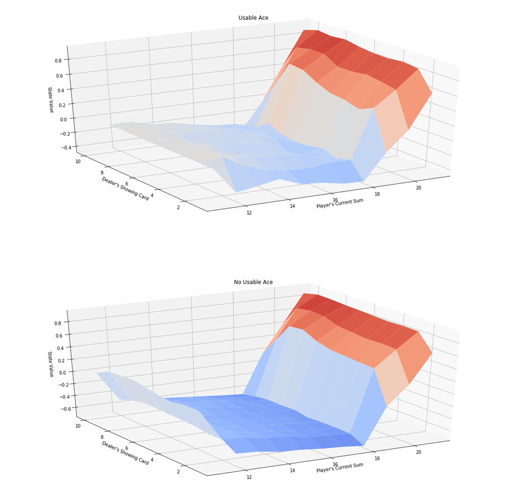

```python
from plot_utils import plot_blackjack_values

# run the iteration with the given policy and
# obtain the value function
V = mc_prediction_v(env, 500000, generate_episode_from_limit)

# plot the value function
plot_blackjack_values(V)
```

### Part 2: MC Prediction: Action Values

In this section, you will write your own implementation of MC prediction (for estimating the action-value function).

We will begin by investigating a policy where the player *almost* always sticks if the sum of her cards exceeds 18. In particular, she selects action `STICK` with 80% probability if the sum is greater than 18; and, if the sum is 18 or below, she selects action `HIT` with 80% probability. The function `generate_episode_from_limit_stochastic` samples an episode using this policy.

The function accepts as **input**:

- `bj_env`: This is an instance of OpenAI Gym's Blackjack environment.

It returns as **output**:

- `episode`: This is a list of (state, action, reward) tuples (of tuples) and corresponds to $(S_0, A_0, R_1, \ldots, S_{T-1}, A_{T-1}, R_{T})$, where $T$ is the final time step. In particular, `episode[i]` returns $(S_i, A_i, R_{i+1})$, and `episode[i][0]`, `episode[i][1]`, and `episode[i][2]` return $S_i$, $A_i$, and $R_{i+1}$, respectively.

```python
def generate_episode_from_limit_stochastic(bj_env):
    episode = []
    state = bj_env.reset()
    while True:
        probs = [0.8, 0.2] if state[0] > 18 else [0.2, 0.8]
        action = np.random.choice(np.arange(2), p=probs)
        next_state, reward, done, info = bj_env.step(action)
        episode.append((state, action, reward))
        state = next_state
        if done:
            break
    return episode
```

```python
# the episodes are the same as before, just the way we created them changed54
episode = generate_episode_from_limit_stochastic(env)
print(episode)
```

```
[((16, 10, False), 1, 0), ((19, 10, False), 1, -1)]
```

Now, you are ready to write your own implementation of MC prediction. Feel free to implement either first-visit or every-visit MC prediction; in the case of the Blackjack environment, the techniques are equivalent.

- `env`: This is an instance of an OpenAI Gym environment.
- `num_episodes`: This is the number of episodes that are generated through agent-environment interaction.
- `generate_episode`: This is a function that returns an episode of interaction.
- `gamma`: This is the discount rate. It must be a value between 0 and 1, inclusive (default value: `1`).

The algorithm returns as output:

- `Q`: This is a dictionary (of one-dimensional arrays) where `Q[s][a]` is the estimated action value corresponding to state `s` and action `a`.

```python
def mc_prediction_q(env, num_episodes, generate_episode, gamma=1.0):
    """this is for counting every visit"""
    # initialize empty dictionaries with stochastic functions, that map both actions to 0

    # returns are collected in lists
    returns = defaultdict(list)

    # loop over episodes
    for i_episode in range(1, num_episodes+1):
        # monitor progress
        if i_episode % 1000 == 0:
            print("\rEpisode {}/{}.".format(i_episode, num_episodes), end="")
            sys.stdout.flush()

        # collect the rewards for all episodes: use all visits
        episode = generate_episode(env)
        states, actions, rewards = zip(*episode)
        discounts = np.array([gamma**i for i in range(len(rewards)+1)])

        # now we need to compute the returns for all state action pairs:
        for i, state in enumerate(states):
            # action is the action taken
            action = actions[i]
            rewards_chain = rewards[i:]
            discount_chain = discounts[:len(rewards_chain)]

            sum_discounted_rewards = sum(rewards_chain * discount_chain)

            returns[(state, action)].append(sum_discounted_rewards)

    Q = defaultdict(lambda: np.zeros(env.action_space.n))
    for state_action_pair, expected_rewards in returns.items():
        action = state_action_pair[1]
        state = state_action_pair[0]
        Q[state][action] = np.mean(expected_rewards)

    return Q
```

Use the cell below to obtain the action-value function estimate $Q$. We have also plotted the corresponding state-value function.

To check the accuracy of your implementation, compare the plot below to the corresponding plot in the solutions notebook **Monte_Carlo_Solution.ipynb**.

```
Episode 500000/500000.
```

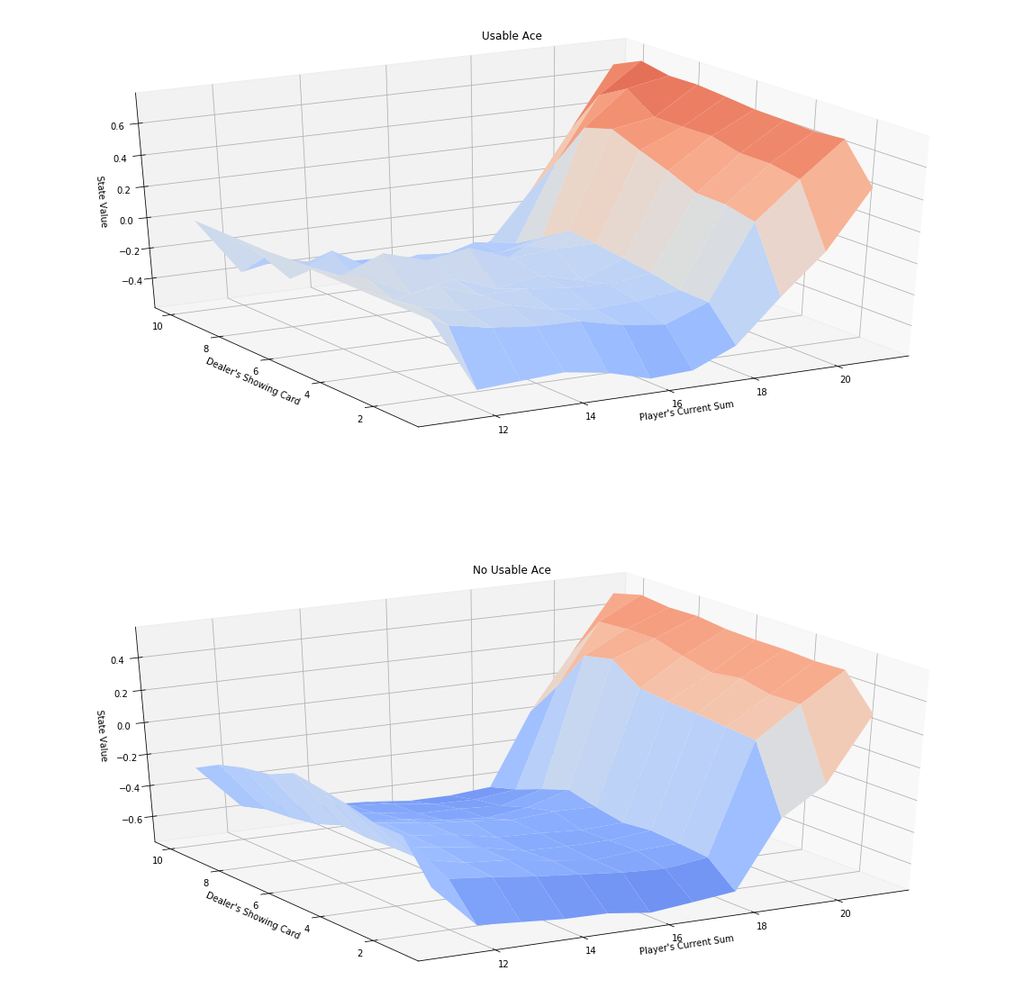

```python
# obtain the action-value function
Q = mc_prediction_q(env, 500000, generate_episode_from_limit_stochastic)

# obtain the state-value function
V_to_plot = dict((k,(k[0]>18)*(np.dot([0.8, 0.2],v)) + (k[0]<=18)*(np.dot([0.2, 0.8],v))) \
         for k, v in Q.items())

# plot the state-value function
plot_blackjack_values(V_to_plot)
```

### Part 3: MC Control: GLIE

Your algorithm has three arguments:

- `env`: This is an instance of an OpenAI Gym environment.
- `num_episodes`: This is the number of episodes that are generated through agent-environment interaction.
- `gamma`: This is the discount rate. It must be a value between 0 and 1, inclusive (default value: `1`).

The algorithm returns as output:

- `Q`: This is a dictionary (of one-dimensional arrays) where `Q[s][a]` is the estimated action value corresponding to state `s` and action `a`.
- `policy`: This is a dictionary where `policy[s]` returns the action that the agent chooses after observing state `s`.

(*Feel free to define additional functions to help you to organize your code.*)

```python
def generate_epsilon_greedy_episode_from_q(env, epsilon, Q, nA):
    episode = []
    state = env.reset()
    p_default_epsilon = epsilon / nA
    p_default = 1 / nA
    while True:
        if state in Q:
            probs = [p_default_epsilon] * nA
            greedy_choice = np.argmax(Q[state])
            probs[greedy_choice] = 1 - epsilon + (epsilon / nA)
        else:
            probs = [p_default] * nA

        action = np.random.choice(np.arange(nA), p=probs)
        next_state, reward, done, info = env.step(action)
        episode.append((state, action, reward))
        state = next_state
        if done:
            break
    return episode
```

```python
def mc_control_GLIE(env, num_episodes, gamma=1.0):
    nA = env.action_space.n
    # initialize empty dictionaries of arrays
    Q = defaultdict(lambda: np.zeros(nA))
    N = defaultdict(lambda: np.zeros(nA))
    # loop over episodes
    for i_episode in range(1, num_episodes+1):
        epsilon = 1.0/((i_episode / 10000) + 1)
        # monitor progress
        if i_episode % 1000 == 0:
            print("\rEpisode {}/{}.".format(i_episode, num_episodes), end="")
            sys.stdout.flush()

        # collect the rewards for all episodes: use all visits
        episode = generate_epsilon_greedy_episode_from_q(env, epsilon, Q, nA)
        states, actions, rewards = zip(*episode)
        discounts = np.array([gamma**i for i in range(len(rewards)+1)])

        for i, state in enumerate(states):
            action = actions[i]
            old_Q = Q[state][action]
            N[state][action] += 1
            rewards_chain = rewards[i:]
            discount_chain = discounts[:len(rewards_chain)]
            sum_discounted_rewards = sum(rewards_chain * discount_chain)

            Q[state][action] = old_Q + (sum_discounted_rewards - old_Q) / N[state][action]

    # for state assign action
    policy = dict((state, np.argmax(action)) for state, action in Q.items())

    return policy, Q
```

Use the cell below to obtain the estimated optimal policy and action-value function.

```python
# obtain the estimated optimal policy and action-value function
policy_glie, Q_glie = mc_control_GLIE(env, 500000)
```

```
Episode 500000/500000.
```

Next, we plot the corresponding state-value function.

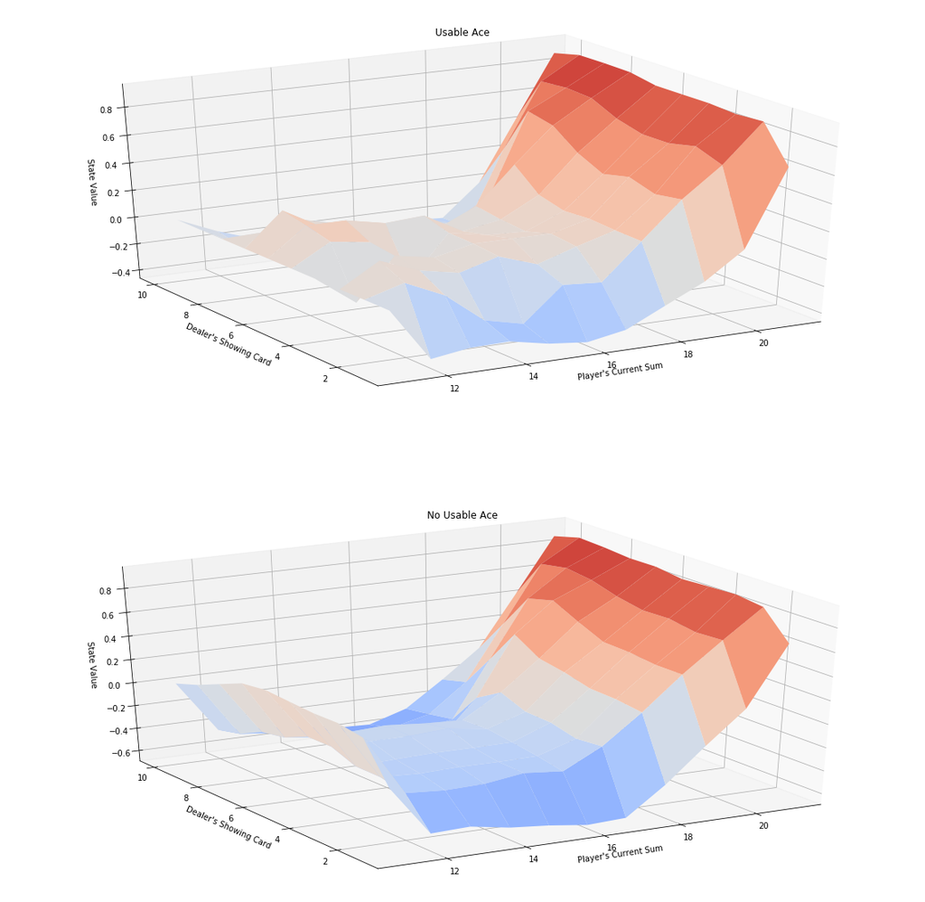

```python
# obtain the state-value function
V_glie = dict((k,np.max(v)) for k, v in Q_glie.items())

# plot the state-value function
plot_blackjack_values(V_glie)
```

Finally, we visualize the policy that is estimated to be optimal.

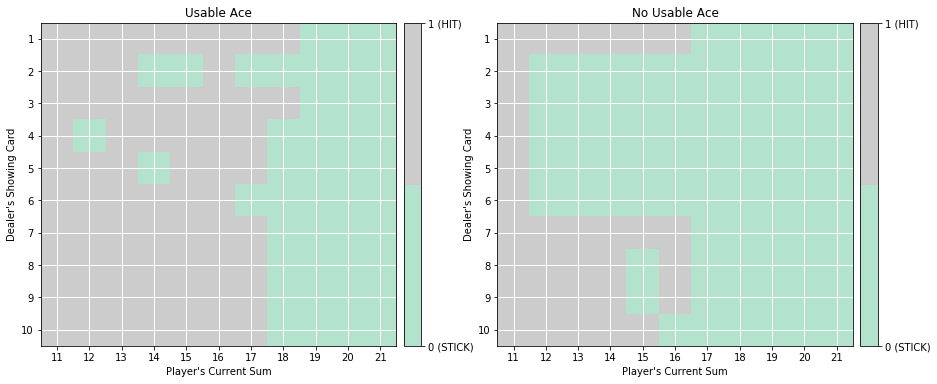

```python
from plot_utils import plot_policy

# plot the policy
plot_policy(policy_glie)
```

The **true** optimal policy $\pi_*$ can be found on page 82 of the textbook (and appears below). Compare your final estimate to the optimal policy - how close are you able to get? If you are not happy with the performance of your algorithm, take the time to tweak the decay rate of $\epsilon$ and/or run the algorithm for more episodes to attain better results.

[figure not shown]

### Part 4: MC Control: Constant-$\alpha$

In this section, you will write your own implementation of constant-$\alpha$ MC control.

Your algorithm has four arguments:

- `env`: This is an instance of an OpenAI Gym environment.
- `num_episodes`: This is the number of episodes that are generated through agent-environment interaction.
- `alpha`: This is the step-size parameter for the update step.
- `gamma`: This is the discount rate. It must be a value between 0 and 1, inclusive (default value: `1`).

The algorithm returns as output:

- `Q`: This is a dictionary (of one-dimensional arrays) where `Q[s][a]` is the estimated action value corresponding to state `s` and action `a`.
- `policy`: This is a dictionary where `policy[s]` returns the action that the agent chooses after observing state `s`.

(*Feel free to define additional functions to help you to organize your code.*)

```python
def mc_control_alpha(env, num_episodes, alpha, gamma=1.0):
    nA = env.action_space.n
    # initialize empty dictionary of arrays
    Q = defaultdict(lambda: np.zeros(nA))
    # loop over episodes
    for i_episode in range(1, num_episodes+1):
        # monitor progress
        if i_episode % 1000 == 0:
            print("\rEpisode {}/{}.".format(i_episode, num_episodes), end="")
            sys.stdout.flush()

        epsilon = 1.0/((i_episode / 10000) + 1)

        # collect the rewards for all episodes: use all visits
        episode = generate_epsilon_greedy_episode_from_q(env, epsilon, Q, nA)
        states, actions, rewards = zip(*episode)
        discounts = np.array([gamma**i for i in range(len(rewards)+1)])

        for i, state in enumerate(states):
            action = actions[i]
            old_Q = Q[state][action]
            rewards_chain = rewards[i:]
            discount_chain = discounts[:len(rewards_chain)]
            sum_discounted_rewards = sum(rewards_chain * discount_chain)

            Q[state][action] = old_Q + (sum_discounted_rewards - old_Q) * alpha

    # for state assign action
    policy = dict((state, np.argmax(action)) for state, action in Q.items())

    return policy, Q
```

Use the cell below to obtain the estimated optimal policy and action-value function.

```python
# obtain the estimated optimal policy and action-value function
policy_alpha, Q_alpha = mc_control_alpha(env, 500000, 0.008)
```

```
Episode 500000/500000.
```

Next, we plot the corresponding state-value function.

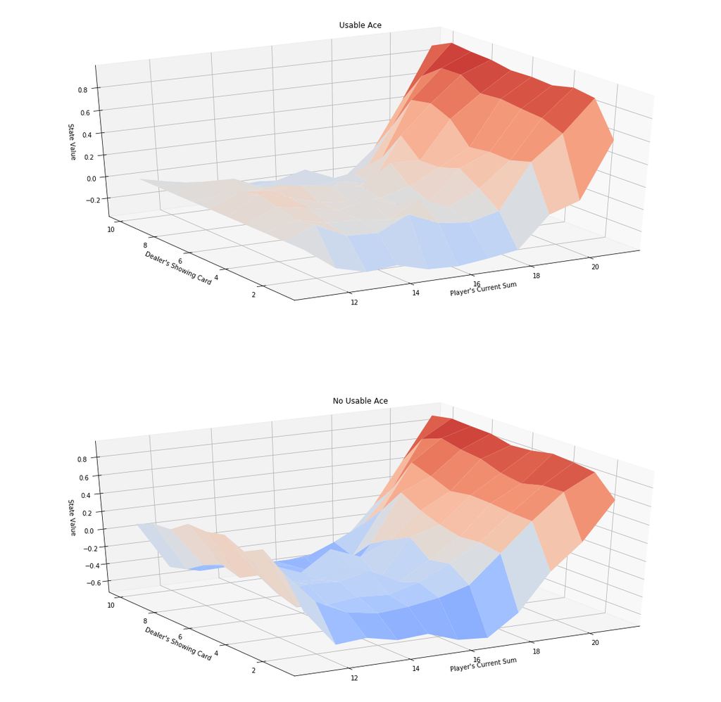

```python
# obtain the state-value function
V_alpha = dict((k,np.max(v)) for k, v in Q_alpha.items())

# plot the state-value function
plot_blackjack_values(V_alpha)
```

Finally, we visualize the policy that is estimated to be optimal.

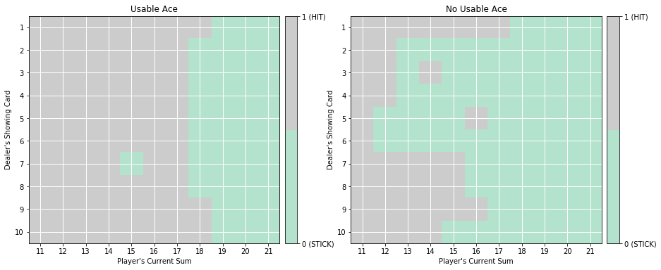

```python
# plot the policy
plot_policy(policy_alpha)
```

The **true** optimal policy $\pi_*$ can be found on page 82 of the textbook (and appears below). Compare your final estimate to the optimal policy - how close are you able to get? If you are not happy with the performance of your algorithm, take the time to tweak the decay rate of $\epsilon$, change the value of $\alpha$, and/or run the algorithm for more episodes to attain better results.

[figure not shown]